# Plotting Using Layers

2018-05-15

## Deepwater Horizon Oil Spill (April 20, 2010)

[figure not shown]

## Datasets

NOAA Data:

- National Oceanic and Atmospheric Administration
- Temperature and Salinity Data in Gulf of Mexico
- Measured using Floats, Gliders and Boats

US Fisheries and Wildlife Data:

- Animal Sightings on the Gulf Coast
- Birds, Turtles and Mammals
- Status: Oil Covered or Not

Both data sources have geographic coordinates for every observation

## Loading NOAA Data

NOAA data is a binary R file so we need to read it specially:

1. Download the data from https://raw.githubusercontent.com/heike/summerschool-2018/master/02-graphics/data/noaa.rdata
2. Run the `getwd()` command to find your current working directory
3. Place noaa.rdata in the directory from step 2.
4. Run the command below:

```r
if (!file.exists("../data/noaa.rdata"))
  download.file("https://raw.githubusercontent.com/heike/summerschool-2018/master/02-graphics/data/noaa.rdata", "../data/noaa.rdata")
load("../data/noaa.rdata")
```

## Floats

Lets take a peek at the top of the floats NOAA data.

```r
head(floats, n = 2)
```

```
##   callSign Date_Time JulianDay Time_QC Latitude Longitude Position_QC
## 1 Q4901043 7/12/2010   2455390       1   24.823   -87.964           1
## 2 Q4901043 7/12/2010   2455390       1   24.823   -87.964           1
##   Depth Depth_QC Temperature Temperature_QC Salinity Salinity_QC  Type
## 1     2        1       29.83              1    36.59           1 Float
## 2     4        1       29.65              1    36.58           1 Float
```

## Floats Plot

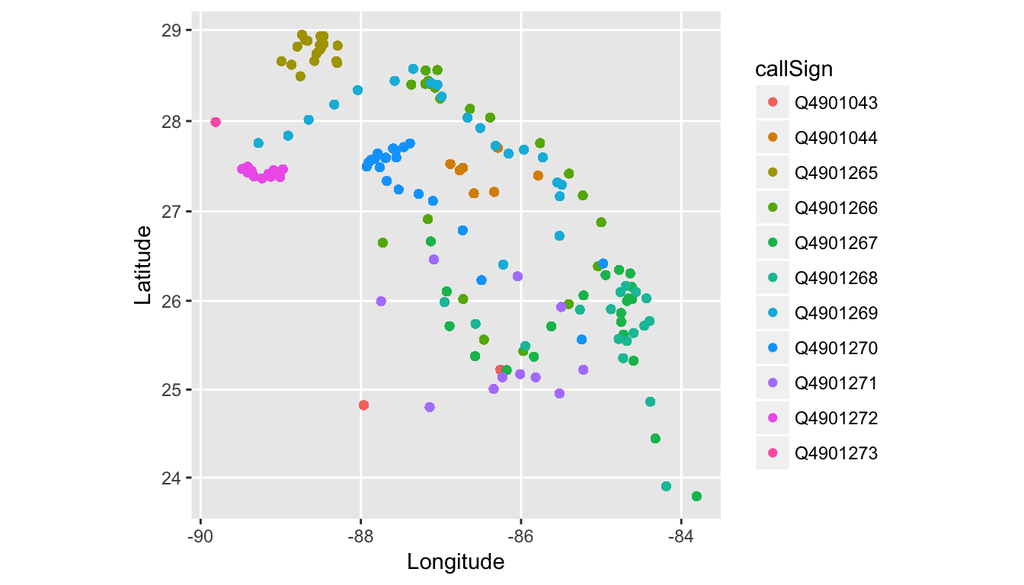

```r
qplot(Longitude, Latitude, colour = callSign, data = floats) +
    coord_map()
```

## Gliders

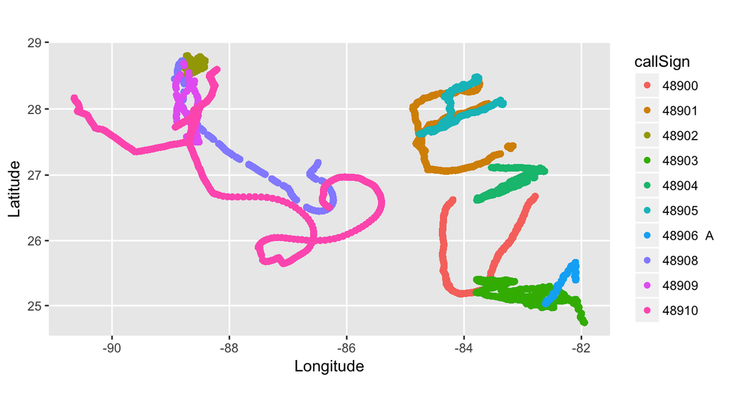

```r
qplot(Longitude, Latitude, colour = callSign, data = gliders) +
    coord_map()
```

## Boats

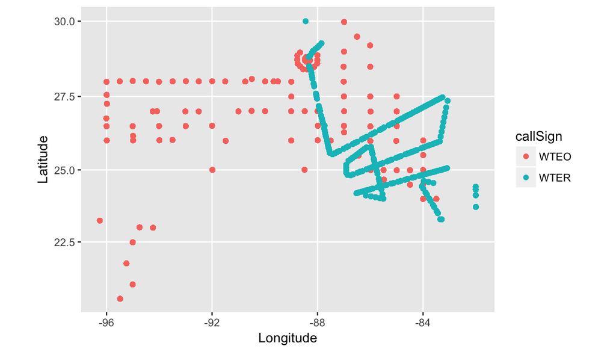

```r
qplot(Longitude, Latitude, colour = callSign, data = boats) +
    coord_map()
```

## Layering

This data has the same context - a common time and common place

- Want to aggregate information from different sources onto a common plot
- Start with a common background the lat/long grid
- With `ggplot2` we will superimpose data onto this grid in layers

## Layers

To give you an idea…

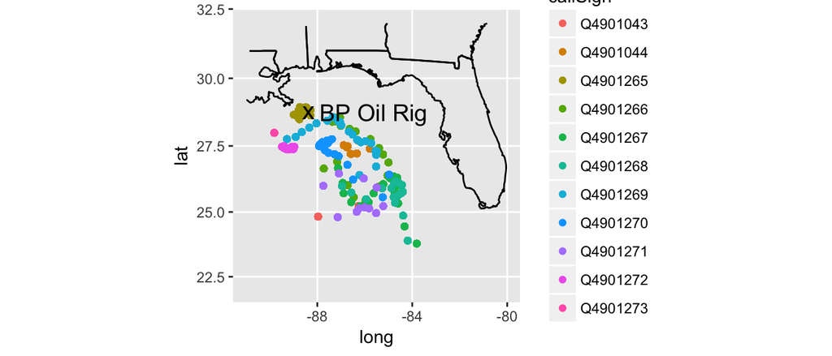

```r
ggplot() +
    geom_path(data = states, aes(x = long, y = lat, group = group)) +
    geom_point(data = floats, aes(x = Longitude, y = Latitude, colour = callSign)) +
    geom_point(aes(x, y), shape = "x", size = 5, data = rig) +
    geom_text(aes(x, y), label = "BP Oil Rig",
              size = 5, data = rig, hjust = -0.1) +
    xlim(c(-91, -80)) + ylim(c(22,32)) + coord_map()
```

## More Layering

- Most maps (and many plots) have multiple layers of data. The layers may be from the same or different datasets.
- ggplot2 builds around this same idea. Very easy to add additional layers to the plot. To do this we need to understand a little more about the underlying theory…

## What is a Plot?

- A default dataset
- A coordinate system
- layers of geometric objects (geoms)
- A set of aesthetic mappings (taking information from the data and converting into an attribute of the plot)
- A scale for each aesthetic
- A facetting specification (multiple plots based on subsetting the data)

## Floats Decomposed

- **Data**: floats
- **Mappings** and **Scales**:

| aesthetic | mapping | scale |
| --- | --- | --- |
| x | Longitude | continuous |
| y | Latitude | continuous |
| color | CallSign | discrete |

- **Layers**: Points
- **Facetting**: None

## `qplot()` vs `ggplot()`

`qplot()` stands for “quickplot”:

- Automatically chooses default settings to make life easier
- Less control over plot construction

`ggplot()` stands for “grammar of graphics plot”

- Constructs the plot using components listed in previous slides

## `qplot()` and `ggplot()` for Floats

Two ways to construct the same plot for float locations:

```r
qplot(Longitude, Latitude, colour = callSign, data = floats)
```

Or:

```r
ggplot(data = floats,
       aes(x = Longitude, y = Latitude, colour = callSign)) +
  geom_point() +
  scale_x_continuous() +
  scale_y_continuous() +
  scale_colour_discrete()
```

## We can shorten that a bit

We fortunately don’t need to be so verbose - even `ggplot()` will automatically pick default scales:

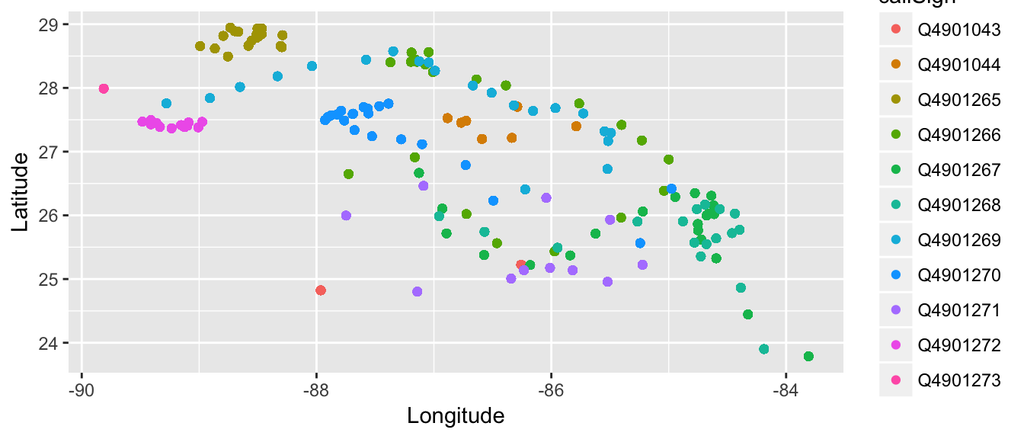

```r
ggplot(data = floats,
       aes(x = Longitude, y = Latitude, colour = callSign)) +
  geom_point()
```

## Your Turn

Find the `ggplot()` statement that creates this plot:

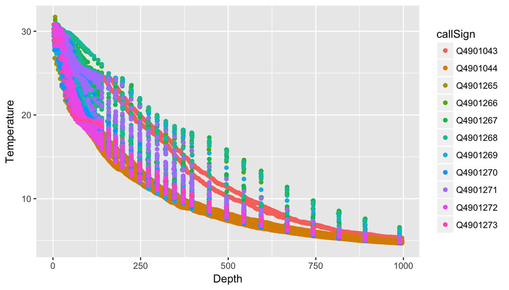

## What is a Layer?

A layer added `ggplot()` can be a geom…

- The type of geometric object
- The statistic mapped to that object
- The data set from which to obtain the statistic

… or a position adjustment to the scales

- Changing the axes scale
- Changing the color gradient

## Layer Examples

| Plot | Geom | Stat |
| --- | --- | --- |
| Scatterplot | point | identity |
| Histogram | bar | bin count |
| Smoother | line + ribbon | smoother function |
| Binned Scatterplot | rectange + color | 2d bin count |

More geoms described at http://ggplot2.tidyverse.org/reference/

## Piecing Things Together

Want to build a map using NOAA data

- Coordinate system (mapping Long-Lat to X-Y)
- Add layer of state outlines
- Add layer of points for float locations
- Add layers for Oil Rig marker and label
- Adjust the range of x and y scales

## The Result

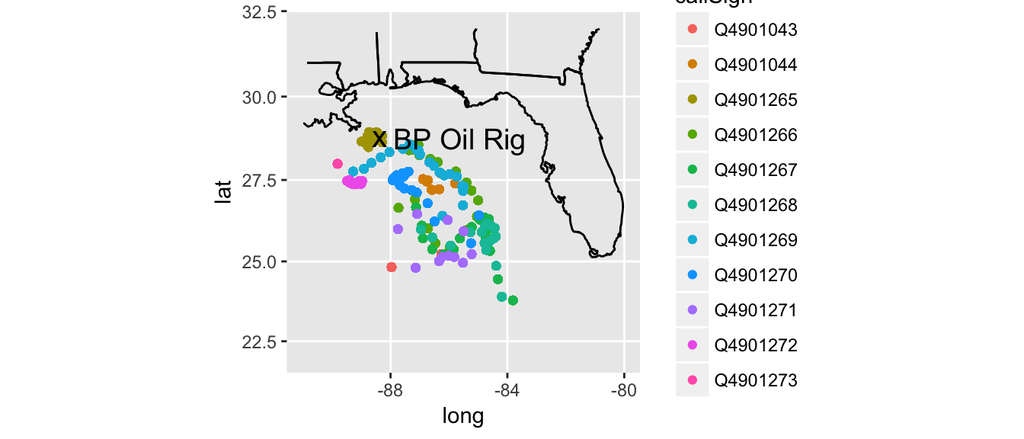

```r
ggplot() +
    geom_path(data = states, aes(x = long, y = lat, group = group)) +
    geom_point(data = floats, aes(x = Longitude, y = Latitude, colour = callSign)) +
    geom_point(aes(x, y), shape = "x", size = 5, data = rig) +
    geom_text(aes(x, y), label = "BP Oil Rig", size = 5, data = rig, hjust = -0.1) +
    xlim(c(-91, -80)) +
    ylim(c(22, 32)) + coord_map()
```

## Your Turn

1. Read in the animal.csv data:

```r
animal <- read.csv("https://raw.githubusercontent.com/heike/summerschool-2018/master/02-graphics/data/animal.csv")
```

1. Plot the location of animal sightings on a map of the region
2. On this plot, try to color points by class of animal and/or status of animal
3. **Advanced**: Could we indicate time somehow?

## One more map …

Using the `ggmap` package, we can download satellite images using the Google Maps API for specified regions of the world

```r
library(ggmap)
gmap <- get_map(location=c(rig$x, rig$y), zoom=6)
```

[figure not shown]

```r
ggmap(gmap, extent = 'normal') +
  geom_point(aes(Longitude, Latitude), shape="+", size=5, colour="black", data=subset(animal, Condition=="Dead")) +
  ggtitle("Crosses indicate locations of sightings of dead bird")
```